# Correlation and Regression Homework

Brianna Shaughnessy

10/15/2018

# 1. Correlation - W&S Chapter 16

## Question 15

#### 15a. Display the association between the two variables in a scatter plot.

```r
Language <- read_csv("../Data/GreyMatter.csv")
```

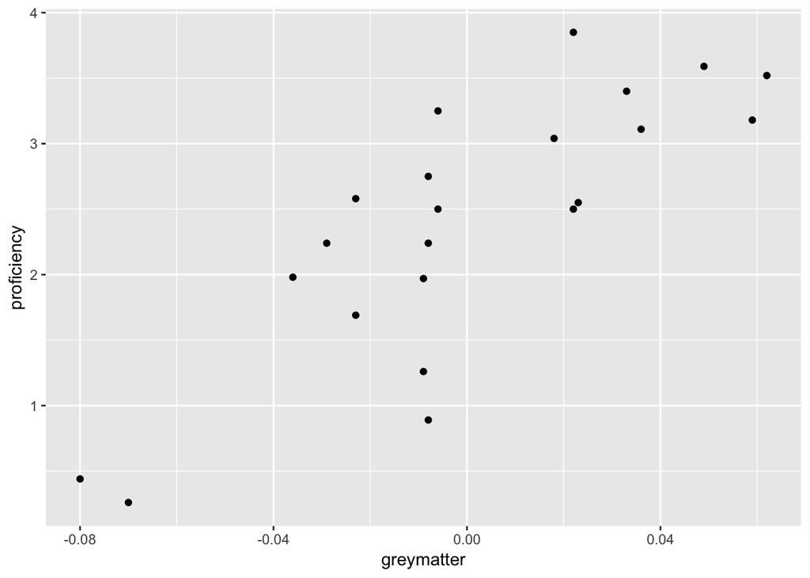

```r
#Explanatory Variable = Grey Matter
#Response variable = Proficiency
Language_Scatter <- ggplot(Language, mapping = aes(x = greymatter,
                                                   y = proficiency))+
  geom_point()
Language_Scatter
```

#### 15b. Calculate the correlation between second language proficiency and gray-matter density.

```r
Language_Mod <- lm(greymatter ~ proficiency, data = Language)
language_cor <- cor.test(Language$greymatter, Language$proficiency)
#Single out the value of the estimated correlation:
language_correlation <- language_cor$estimate
language_correlation
```

```
##       cor
## 0.8183134
```

#### 15c. Test the null hypothesis of zero correlation.

Our t-statistic is 6.36 with 20 degrees of freedom with a very small p-value (3.264 e-06), allowing us to reject the null hypothesis of zero correlation.

```r
#T-Test of zero correlation: included in the output of cor.test
cor.test(Language$greymatter, Language$proficiency)
```

```
##
##  Pearson's product-moment correlation
##
## data:  Language$greymatter and Language$proficiency
## t = 6.3671, df = 20, p-value = 3.264e-06
## alternative hypothesis: true correlation is not equal to 0
## 95 percent confidence interval:
##  0.6056638 0.9218696
## sample estimates:
##       cor
## 0.8183134
```

#### 15d. What are your assumptions in part (c)?

**1)** Observations are from a random sample  
**2)** Each observation is independent  
**3)** X and Y are from a Normal Distribution

#### 15e. Does the scatter plot support these assumptions? Explain.

Our initial scatter plot does not support our assumptions. There are two outliers that can be seen. If we fit a model and look at the residuals and qq plot they also do not quite meet the assumptions of normality.

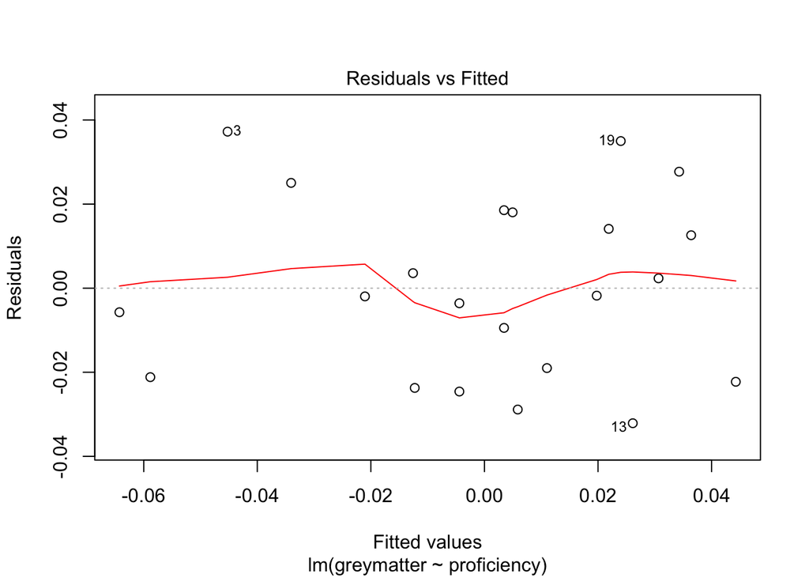

```r
plot(Language_Mod, which = 1)
```

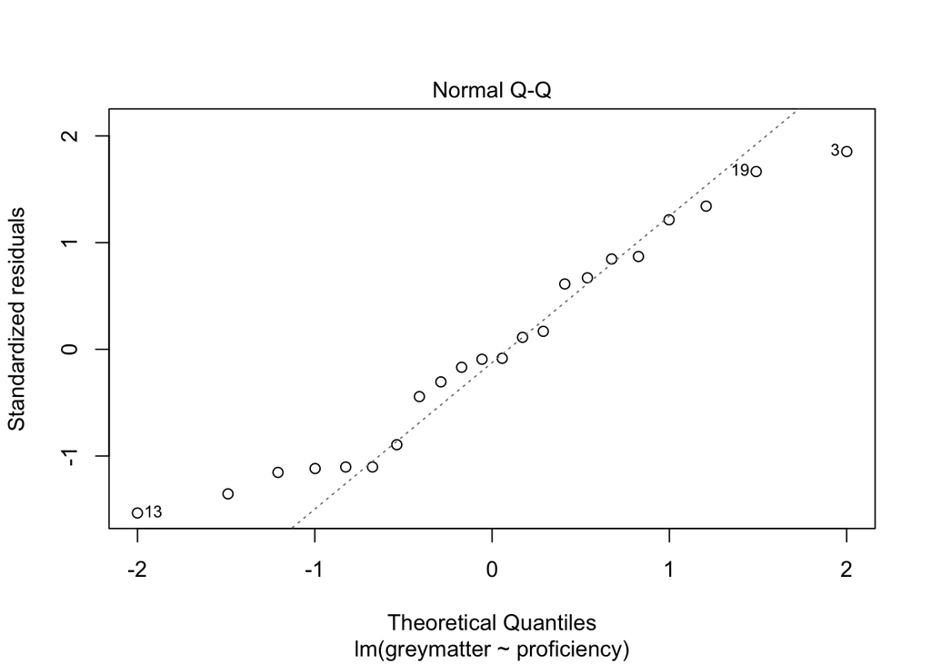

```r
plot(Language_Mod, which = 2)
```

## Question 19

#### 19a. Calculate the correlation coefficient between the taurocholate unbound fraction and the concentration.

-0.856

```r
Liver <- read_csv("../Data/LiverPreparation.csv")
liver_cor <- cor.test(Liver$concentration, Liver$unboundFraction)
#Single out the value of the estimated correlation:
liver_cor_value <- liver_cor$estimate
liver_cor_value
```

```
##        cor
## -0.8563765
```

#### 19b.Plot the relationship between the two variables in a graph.

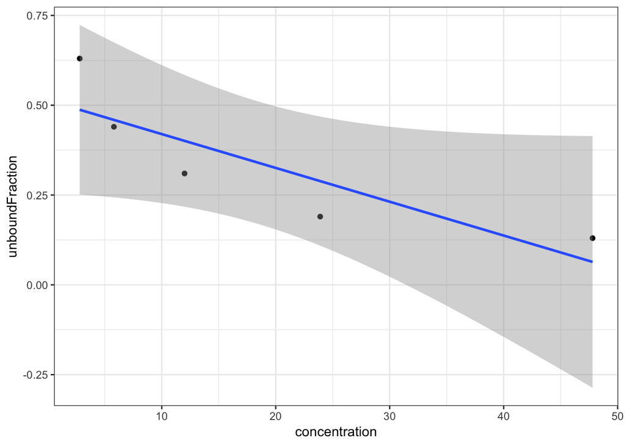

```r
liver_base <- ggplot(data = Liver, mapping = aes(x = concentration,
                            y = unboundFraction)) +
  geom_point() + theme_bw()
liver_base +
  stat_smooth(method = "lm")
```

#### 19c. Examine the plot in part (b). The relationship appears to be maximally strong, yet the correlation coefficient you calculated in part (a) is not near the maximum possible value. Why not?

This relationship may not be linear.

#### 19d. What steps would you take with these data to meet the assumptions of correlation analysis?

A lot-transformation may be appropriate here.

# 2. Correlation SE

Consider the following dataset:

```r
cat_happiness <- data_frame(cats = c(-0.30, 0.42, 0.85, -0.45, 0.22,-0.12, 1.46, -0.79, 0.40, -0.07),
        happiness_score = c(-0.57, -0.10, -0.04,-0.29, 0.42, -0.92, 0.99, -0.62, 1.14, 0.33))
cat_happiness
```

```
## # A tibble: 10 x 2
##     cats happiness_score
##    <dbl>           <dbl>
##  1 -0.3           -0.570
##  2  0.42          -0.1
##  3  0.85          -0.04
##  4 -0.45          -0.290
##  5  0.22           0.42
##  6 -0.12          -0.92
##  7  1.46           0.99
##  8 -0.79          -0.62
##  9  0.4            1.14
## 10 -0.07           0.33
```

#### 2a. Are these two variables correlated? What is the output of `cor()` here? What does a test show you?

The two variables do seem correlated based on our estimated correlation and (somewhat) low p-value. Output of `cor()` is our estimated correlation of 0.676  
The output of a test `cor.test()` gives us more information including our T-statistic of 2.59 with 8 degrees of freedom, our p-value of 0.032, and our 95% Confidence interval.

```r
cor(cat_happiness$cats, cat_happiness$happiness_score)
```

```
## [1] 0.6758738
```

```r
cor.test(cat_happiness$cats, cat_happiness$happiness_score)
```

```
##
##  Pearson's product-moment correlation
##
## data:  cat_happiness$cats and cat_happiness$happiness_score
## t = 2.5938, df = 8, p-value = 0.03193
## alternative hypothesis: true correlation is not equal to 0
## 95 percent confidence interval:
##  0.08050709 0.91578829
## sample estimates:
##       cor
## 0.6758738
```

#### 2c. Now, what is the SE via simulation? To do this, you’ll need to use `cor()` and get the relevant parameter from the output (remember - you get a matrix back, so, what’s the right index!), `replicate()`, and `sample()` or `dplyr::sample_n()` with `replace = TRUE` to get, let’s say, 1000 correlations. How does this compare to your value above?

```r
simulation_SE <- replicate(1000, cor(sample_n(cat_happiness, nrow(cat_happiness), replace = TRUE)) [1,2])

sd(simulation_SE)
```

```
## [1] 0.1500609
```

# 3. W&S Chapter 17

## Question 19

#### 19a. Draw a scatter plot of these data. Which variable should be the explanatory variable (X), and which should be the response variable (Y)?

**Explanatory Variable (X)** Nutrients  
**Response Variable (Y)** Species

```r
PlantSpecies <- read_csv("../Data/PlantSpecies.csv")
```

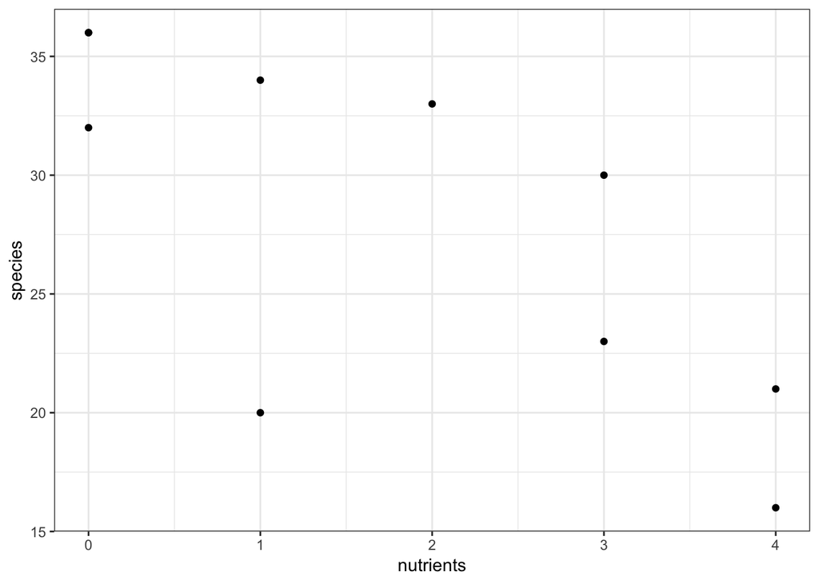

```r
plant_scatter <- ggplot(data = PlantSpecies,
                        mapping = aes(x = `nutrients`,
                                      y = `species`)) +
  geom_point() + theme_bw()
plant_scatter
```

#### 19b. What is the rate of change in the number of plant species supported per nutrient type added? Provide a standard error for your estimate.

```r
# Fit the Model
plant_lm <- lm(nutrients ~ species, data = PlantSpecies)
plant_lm
```

```
##
## Call:
## lm(formula = nutrients ~ species, data = PlantSpecies)
##
## Coefficients:
## (Intercept)      species
##      6.3107      -0.1605
```

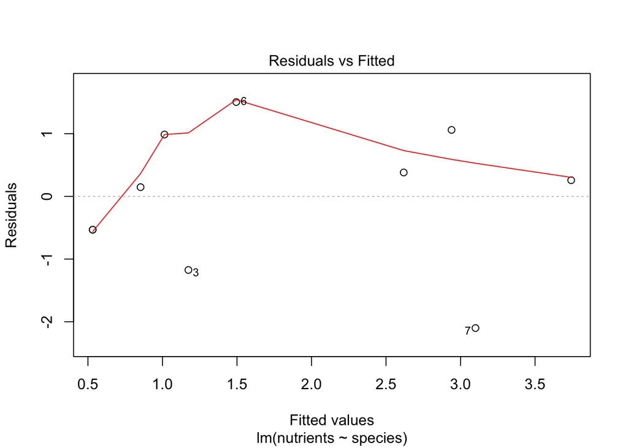

```r
# Fit Assumptions of the Model
plot(plant_lm, which = 1)
```

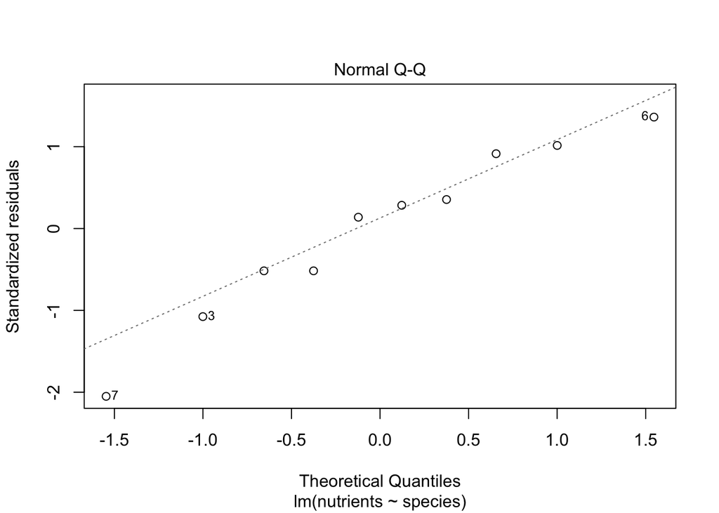

```r
plot(plant_lm, which = 2)
```

```r
#3. Evaluate the Model Itself
summary(plant_lm)
```

```
##
## Call:
## lm(formula = nutrients ~ species, data = PlantSpecies)
##
## Residuals:
##     Min      1Q  Median      3Q     Max
## -2.1002 -0.5319  0.2024  0.8353  1.5050
##
## Coefficients:
##             Estimate Std. Error t value Pr(>|t|)
## (Intercept)  6.31065    1.52928   4.127  0.00331 **
## species     -0.16052    0.05281  -3.040  0.01607 *
## ---
## Signif. codes:  0 '***' 0.001 '**' 0.01 '*' 0.05 '.' 0.1 ' ' 1
##
## Residual standard error: 1.17 on 8 degrees of freedom
## Multiple R-squared:  0.536,  Adjusted R-squared:  0.478
## F-statistic: 9.241 on 1 and 8 DF,  p-value: 0.01607
```

```r
#Pull rate from t-value?
```

#### 19c. Add the least-squares regression line to your scatter plot. What fraction of the variation in the number of plant species is “explained” by the number of nutrients added?

Our R-squared value is 0.536, equal to the fraction of variation in the number of plant species that is “explained” by the number of nutrients added.

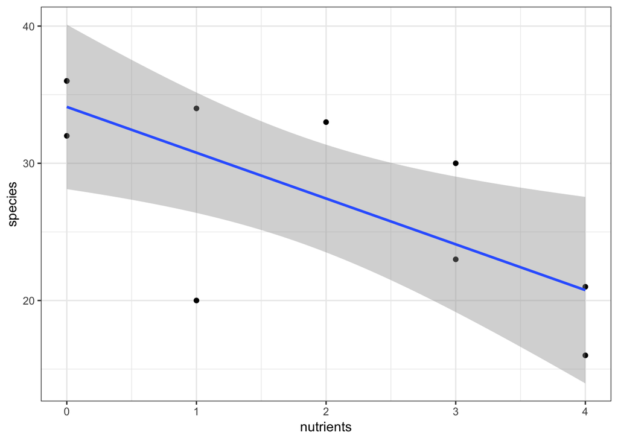

```r
#Add regression line
plant_scatter +
  stat_smooth(method = lm, formula = y~x)
```

#### 19d. Test the null hypothesis of no treatment effect on the number of plant species.

Our p-value is less than 0.05 (0.01607) allowing us to reject our null hypothesis of no treatment effect on the number of plant species.

```r
#F-Test of the model
anova(plant_lm)
```

```
## Analysis of Variance Table
##
## Response: nutrients
##           Df Sum Sq Mean Sq F value  Pr(>F)
## species    1 12.649 12.6491  9.2406 0.01607 *
## Residuals  8 10.951  1.3689
## ---
## Signif. codes:  0 '***' 0.001 '**' 0.01 '*' 0.05 '.' 0.1 ' ' 1
```

## Question 30

#### 30a. What is the approximate slope of the regression line?

-16.71

```r
Teeth <- read_csv("../Data/NuclearTeeth.csv")
teeth_lm <- lm(deltaC14 ~ dateOfBirth, data = Teeth)
teeth_lm
```

```
##
## Call:
## lm(formula = deltaC14 ~ dateOfBirth, data = Teeth)
##
## Coefficients:
## (Intercept)  dateOfBirth
##    33318.21       -16.71
```

#### 30b. Which pair of lines shows the confidence bands? What do these confidence bands tell us?

The inner dashed lines show the confidence bands. The confidence bands visualize the 95% Confidence Interval for the prediced mean Date of Birth at a given delta C14.

#### 30c. Which pair of lines shows the prediction interval? What does this prediction interval tell us?

The outer dashed lines show the prediction interval. The prediction interval visualizes the uncertainty when predicting the Date of Birth of a single individual.

## Question 31

#### 31a. Calculate a regression line that best describes the relationship between year of painting and the portion size. What is the trend? How rapidly has portion size changed in paintings?

```r
PortionSize <- read_csv("../Data/LastSupper.csv")
portion_lm <- lm(year ~ portionSize, data = PortionSize)
portion_lm
```

```
##
## Call:
## lm(formula = year ~ portionSize, data = PortionSize)
##
## Coefficients:
## (Intercept)  portionSize
##     1130.74        82.64
```

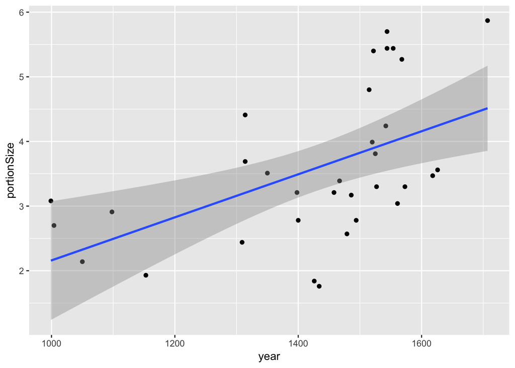

```r
portion_base <- ggplot(data = PortionSize, mapping = aes(x = `year`,
                                                y = `portionSize`)) +
  geom_point()

portion_regression <- portion_base +
  stat_smooth(method = "lm")
portion_regression
```

#### 31b. What is the most-plausible range of values for the slope of this relationship? Calculate a 95% Confidence Interval.

```r
summary(portion_lm)
```

```
##
## Call:
## lm(formula = year ~ portionSize, data = PortionSize)
##
## Residuals:
##     Min      1Q  Median      3Q     Max
## -386.29  -57.82   39.50  123.53  201.04
##
## Coefficients:
##             Estimate Std. Error t value Pr(>|t|)
## (Intercept)  1130.74      90.53   12.49 1.23e-13 ***
## portionSize    82.64      24.09    3.43  0.00173 **
## ---
## Signif. codes:  0 '***' 0.001 '**' 0.01 '*' 0.05 '.' 0.1 ' ' 1
##
## Residual standard error: 157.7 on 31 degrees of freedom
## Multiple R-squared:  0.2751, Adjusted R-squared:  0.2517
## F-statistic: 11.77 on 1 and 31 DF,  p-value: 0.001727
```

#### 31c. Test for a change in relative portion size painted in these works of art with the year in which they were painted.

```r
anova(portion_lm)
```

```
## Analysis of Variance Table
##
## Response: year
##             Df Sum Sq Mean Sq F value   Pr(>F)
## portionSize  1 292501  292501  11.765 0.001727 **
## Residuals   31 770689   24861
## ---
## Signif. codes:  0 '***' 0.001 '**' 0.01 '*' 0.05 '.' 0.1 ' ' 1
```

#### 31d. Draw a residual plot of these data and examine it carefully. Can you see any cause for concern about using a linear regression? Suggest an approach that could be tried to address the problem.

Our residuals are scewed and do not meet the assumptions of a linear regression. Transformations of X and Y could be used to render this nonlinear relationship linear. A log-transformation may be appropriate here.

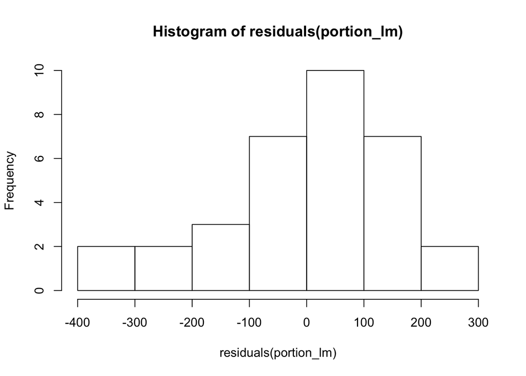

```r
hist(residuals(portion_lm))
```

# 4. Intervals and Simulation

Fit the deet and bites model from lab

```r
deet <- read_csv("../Data/DEET.csv")
```

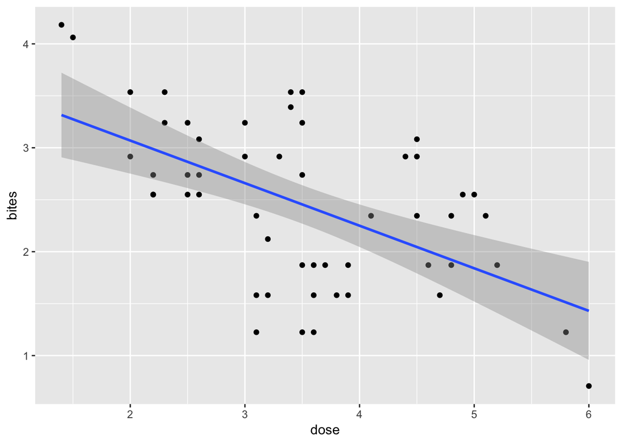

```r
deet_fit <- ggplot(deet, aes(dose, bites)) +
  geom_point() +
  stat_smooth(method = lm)
deet_fit
```

Now, look at `vcov()` applied to your fit. For example:

```r
deet_mod <- lm(bites~dose, data = deet)
vcov(deet_mod)
```

```
##             (Intercept)         dose
## (Intercept)  0.09929780 -0.025986850
## dose        -0.02598685  0.007437073
```

What you have here is the variance-covariance matrix of the parameters of the model. In essence, larger slopes in this case will have smaller intercepts, and vice-verse. This maintains the best fit possible, despite deviations in the slope and intercept. BUT - what’s cool about this is that it also allows us to produce simulations (posterior simulations for anyone interested) of the fit. We can use a package like mnormt that let’s us draw from a multivariate normal distribution when provided with a vcov matrix. For example…

```r
library(mnormt)
 rmnorm(4, mean = coef(deet_mod), varcov = vcov(deet_mod))
```

```
##      (Intercept)       dose
## [1,]    3.906231 -0.4198365
## [2,]    4.242802 -0.5476551
## [3,]    4.093560 -0.4646021
## [4,]    3.897659 -0.4238902
```

#### 4a. Fit Simulations

Using `geom_abline()` make a plot that has the following layers and shows that these simulated lines match up well with the fit CI. 1) the data, 2) the lm fit with a CI, and 3) simulated lines. You might have to mess around to make it look as good as possible.

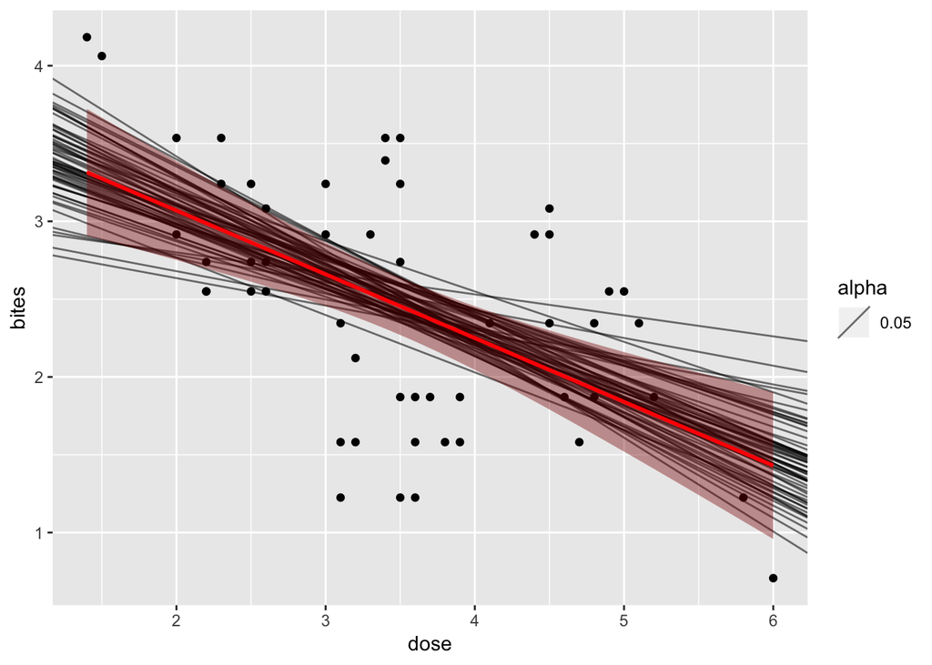

```r
library(mnormt)
# create simulations
simulation <- rmnorm(60, mean = coef(deet_mod), varcov = vcov(deet_mod)) %>%
  as.data.frame
# Create ggplot
ggplot(data = deet, mapping = aes(dose, bites)) +
  geom_point() +
# add simulated lines using abline
  geom_abline(data = simulation, aes(slope = dose, intercept = `(Intercept)`, alpha = 0.05)) +
#looks better if I add lm fit with CI after the ablines are added.
  stat_smooth(data = deet, method = lm, color = "red", fill = "darkred")
```

#### 4b. Prediction Simulations

That’s all well and good, but what about the prediction intervals? To each line, we can add some error drawn from the residual standard deviation. That residual can either be extracted from `summary()` or you can get the sd of residuals.

```r
simulation <- simulation %>%
  mutate(error = rnorm(n(), 0, sd(deet_mod$residuals)))
```

Now, visualize the simulated prediction interval around the fit versus the calculated prediction interval around the fit via predict. +1 extra credit for a clever visualization of all elements on one figure - however you would like

```r
prediction_data <- predict(deet_mod, interval = "prediction")%>%
  cbind(deet)
```

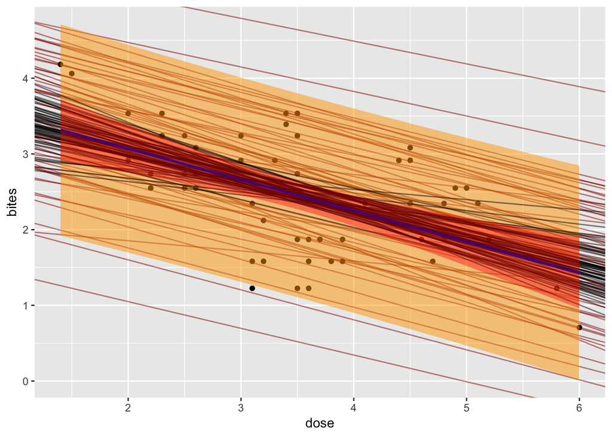

```r
ggplot(data = deet, mapping = aes(dose, bites)) +
#plot our data points
  geom_point() +
#plot our simulated values
  geom_abline(data = simulation, aes(slope = dose, intercept = error+`(Intercept)`), alpha = 0.5, color = "darkred") +
#Plot our predicted values
  geom_ribbon(data = prediction_data, aes(ymin = lwr, ymax = upr), fill = "orange", alpha = 0.5) +
  geom_abline(data = simulation, aes(slope = dose, intercept = `(Intercept)`), alpha = 0.5) +
  stat_smooth(data = deet, method = lm, color = "purple4", fill = "red")
```